# Therapeutic Touch

This is an example from Kruschke(2015)[^1], section 9.2.4. The model is implemented in JAGS in the book.

```r
library(nimble)
library(dplyr)
library(coda)
source("DBDA2E-utilities.R")
```

Practitioners of the therapeutic touch claim that they can sense people’s “energy field.” Rosa et al. (1998)[^2] investigaed this claim via an experiment. The experimenter chose one of the practitioner’s hands randomly on each trial and approached it. Data were collected on whether or not a practitioner was able to sense which of their hands was approached.

The data are shown below. The column `s` contains the identifiers of the practitioners. There were 21 practitioners tested and 7 of them were tested twice. However, retests were counted as separate from the authors, yielding to 28 subjcets in total. The column `y` contains the outcomes, with $1$ meaning that the practitioner answered correctly the hand being approached and $0$ meaning that the practitioner gave the wrong answer. Each practitioner was tested 10 times.

```r
dataTouch <- read.csv('TherapeuticTouchData.csv')
dataTouch <- mutate(dataTouch, s = as.numeric(dataTouch$s))
head(dataTouch)
```

```
##   y s
## 1 1 1
## 2 0 1
## 3 0 1
## 4 0 1
## 5 0 1
## 6 0 1
```

The data is modeled with a hierarchical model. The probability each subject answers a question correctly is modeled with a bernoulli distribution, with the parameters $\theta_1$, … $\theta_{28}$, respectively. The $\theta$’s are assumed to come from a Beta($\omega(\kappa-2)+1,~ (1-\omega)(\kappa-2)+1$) distribution. The parameter $\omega$ represents the mode of the distribution, and can be interepreted as an estimate of the correction rate of the whole group of practitioners. It is assumed to have a Beta prior. The $\kappa$ parameter quantifies the prior certainty regarding the dependence of the probabitilies $\theta$’s on $\omega$. A Gamma prior is put on $\kappa-2$. The following code specifies these assumptions.

```r
## modelCode
code <- nimbleCode({
  omega ~ dbeta(1, 1)
  kappaMinusTwo ~ dgamma(0.01, 0.01)
  kappa <- kappaMinusTwo + 2
  for (i in 1:nSubj){
    theta[i] ~ dbeta( omega*(kappa-2)+1, (1-omega)*(kappa-2)+1 )
  }
  for (i in 1:nTotal){
    y[i] ~ dbern(theta[s[i]])
  }
})

## define additional information needed for the model

nSubj <- length(unique(dataTouch$s)) # number of subjects
thetaInits <- rep(0, nSubj) # initial values of theta
for (i in 1:nSubj){
  thetaInits[i] <- filter(dataTouch, s == i)$y %>% mean()
}
meanThetaInits <- mean(thetaInits) # initial value of omega
kappaInit <- 100 # initial value of kappa

## data
data <- list(y = dataTouch$y)

## constants of the model (e.g. number of observations, fixed values)
consts <- list(s = dataTouch$s, nTotal = nrow(dataTouch), nSubj = nSubj)

## values to initialize the algorithm
inits <- list(theta = thetaInits, omega = meanThetaInits,
              kappaMinusTwo = kappaInit - 2)
```

```r
## fast use of NIMBLE (one-line invocation)
mcmcOut <- nimbleMCMC(code = code, constants = consts,
                        data = data, inits = inits,
                        niter = 20000, nburnin = 2000, thin = 10, nchains = 1,
                        monitors = c('theta', 'omega', 'kappa'))
```

```
## defining model...
```

```
## building model...
```

```
## setting data and initial values...
```

[output not shown]

```
## |-------------|-------------|-------------|-------------|
## |-------------------------------------------------------|
```

```r
## convert posterior samples to mcmc object
mcmcCoda <- as.mcmc(mcmcOut)
```

### Results

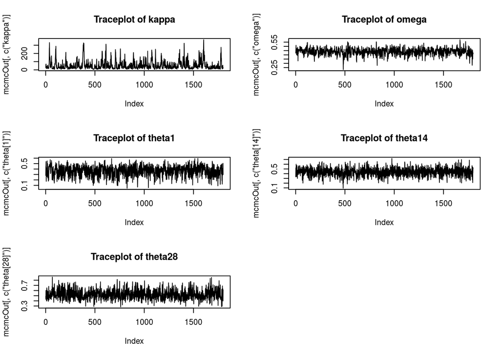

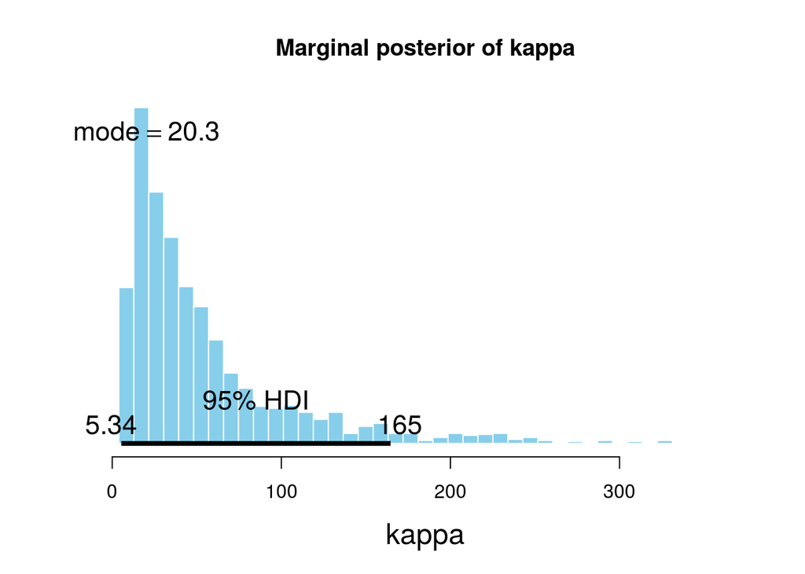

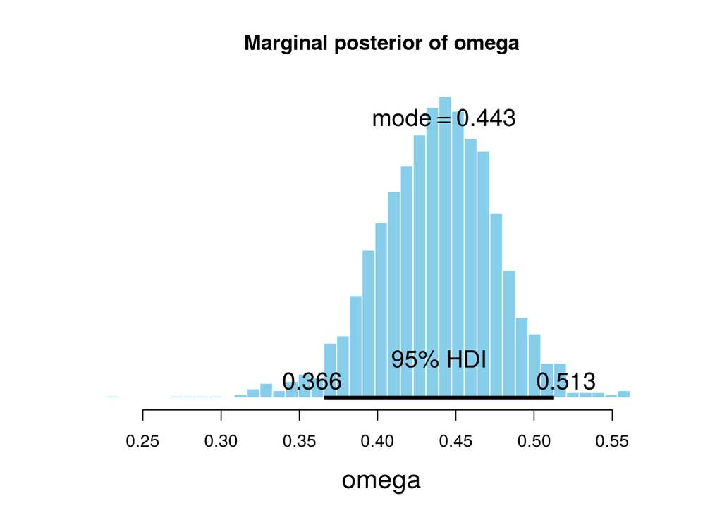

The 95% HDI of $\omega$ contains value 0.5, encoding guessing by chance, so the group of practitioners as a whole cannot be said to be able to sense people’s “energy field.”

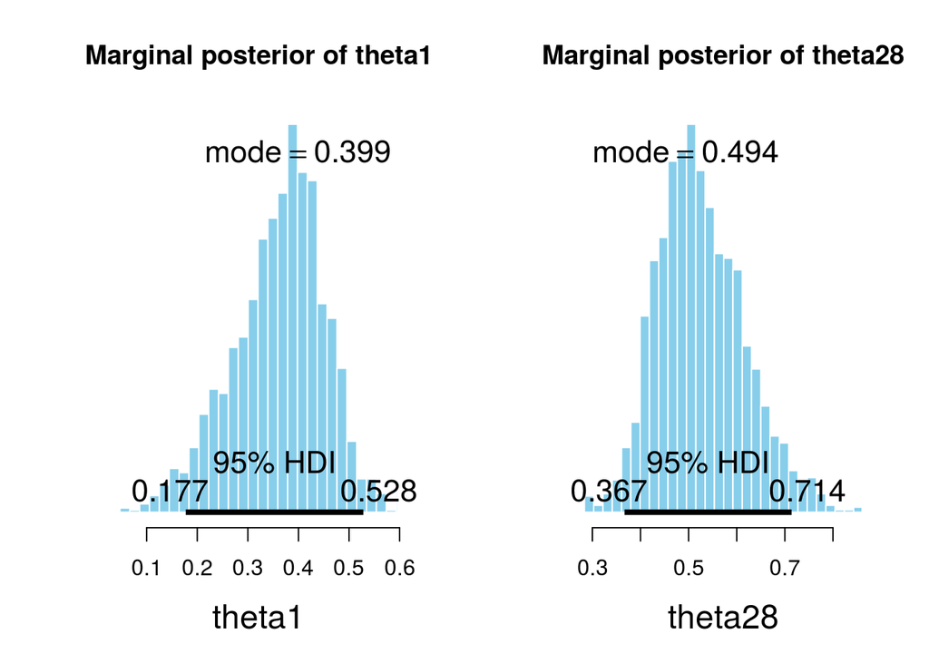

These are the posterior distributions of $\theta_1$ (which corresponds to the practitioner that has the worst performance), and $\theta_{28}$ (the best practitioner). The value 0.5 is in both HDI’s, so it cannot be concluded that any of the pracitioners is able to sense people’s “energy field.”

[^1]: Kruschke, J.K.,2015. Doing Bayesian data analysis: a tutorial with R, JAGS, and stan. 2E [edition]. Academic Press.
[^2]: Rosa, L., Rosa, E., Sarner, L., & Barrett, S. (1998). A close look at therapeutic touch. *Jounal of the American Medical Association*, 279(13), 1005-1010.